# Honor Code

# Summary:

### Note: The analysis for GSK is not shown as it will take much space in report and to keep the report simple and clear.

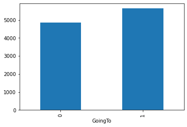

```python
df.groupby('GoingTo')['Distance'].sum().plot.bar()
```

### Barplot depicting relationship between GoingTo and Distance.

# Question

## How does destination column GoingTo affects the TotalTime?

```python
#Describe shows a quick statistic summary of the data
df.describe()
```

|  | DayOfWeek | GoingTo | Distance | MaxSpeed | AvgMovingSpeed | AvgSpeed | FuelEconomy | TotalTime | MovingTime | Highway |
| --- | --- | --- | --- | --- | --- | --- | --- | --- | --- | --- |
| count | 205.000000 | 205.000000 | 205.000000 | 205.000000 | 205.000000 | 205.000000 | 205.000000 | 205.000000 | 205.000000 | 205.000000 |
| mean | 2.863415 | 0.541463 | 51.070956 | 127.569707 | 81.975610 | 74.477561 | 8.690537 | 41.904390 | 37.871707 | 0.170732 |
| std | 1.313907 | 0.499498 | 1.372235 | 4.109319 | 10.111544 | 11.409816 | 0.480881 | 6.849476 | 4.835072 | 0.377195 |
| min | 1.000000 | 0.000000 | 48.320000 | 112.200000 | 50.300000 | 38.100000 | 7.810000 | 28.200000 | 27.100000 | 0.000000 |
| 25% | 2.000000 | 0.000000 | 50.650000 | 124.900000 | 76.600000 | 68.900000 | 8.370000 | 38.400000 | 35.700000 | 0.000000 |
| 50% | 3.000000 | 1.000000 | 51.140000 | 127.400000 | 81.400000 | 73.600000 | 8.540000 | 41.300000 | 37.600000 | 0.000000 |
| 75% | 4.000000 | 1.000000 | 51.640000 | 129.700000 | 86.000000 | 79.900000 | 8.930000 | 44.400000 | 39.900000 | 0.000000 |
| max | 5.000000 | 1.000000 | 60.320000 | 140.900000 | 112.100000 | 107.700000 | 10.050000 | 82.300000 | 62.400000 | 1.000000 |

```python
df[(df['GoingTo'] == 1) & (df['TotalTime'] >= 35)]
```

|  | Date | StartTime | DayOfWeek | GoingTo | Distance | MaxSpeed | AvgMovingSpeed | AvgSpeed | FuelEconomy | TotalTime | MovingTime | Highway |
| --- | --- | --- | --- | --- | --- | --- | --- | --- | --- | --- | --- | --- |
| 1 | 01/06/12 | 8:20 | 5 | 1 | 51.630 | 130.3 | 88.9 | 81.8 | 8.69 | 37.9 | 34.9 | 0 |
| 2 | 01/04/12 | 16:17 | 3 | 1 | 51.270 | 127.4 | 85.8 | 82.0 | 8.69 | 37.5 | 35.9 | 0 |
| 3 | 01/04/12 | 7:53 | 3 | 1 | 49.170 | 132.3 | 82.9 | 74.2 | 8.69 | 39.8 | 35.6 | 0 |
| 5 | 01/03/12 | 7:57 | 2 | 1 | 51.800 | 135.8 | 88.8 | 84.5 | 8.69 | 36.8 | 35.0 | 0 |
| 7 | 01/02/12 | 7:34 | 1 | 1 | 49.010 | 128.3 | 85.9 | 77.5 | 8.69 | 37.9 | 34.3 | 0 |
| ... | ... | ... | ... | ... | ... | ... | ... | ... | ... | ... | ... | ... |
| 195 | 7/21/2011 | 7:59 | 4 | 1 | 48.350 | 129.3 | 89.0 | 81.5 | 8.28 | 35.6 | 32.6 | 1 |
| 197 | 7/20/2011 | 8:24 | 3 | 1 | 53.314 | 125.8 | 87.3 | 75.7 | 7.89 | 38.5 | 33.3 | 1 |
| 199 | 7/19/2011 | 8:11 | 2 | 1 | 50.960 | 124.3 | 96.4 | 82.3 | 7.89 | 37.2 | 31.7 | 1 |
| 200 | 7/18/2011 | 8:09 | 1 | 1 | 54.520 | 125.6 | 82.4 | 49.9 | 7.89 | 65.5 | 39.7 | 0 |
| 201 | 7/14/2011 | 8:03 | 4 | 1 | 50.900 | 123.7 | 95.1 | 76.2 | 7.89 | 40.1 | 32.1 | 1 |

93 rows × 12 columns

# Summary

### So when going to GSK the time taken is greater than 35 minutes for 93 instances.

### So going to GSK the the time taken is most of the times as more than 93 times.

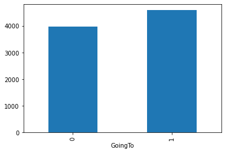

```python
df.groupby('GoingTo')['TotalTime'].sum().plot.bar()
```

### Barplot depicting relationship between GoingTo and TotalTime.

# Final Summary of the report findings:

## The first finding is how average speed is affecting the fuel price.

## The second finding is how the taking highway road is affecting the distance that the driver has to drive.

## The third finding is how the destination is affecting the distance the driver has to drive.

## And final finding is how the destination is affecting the time the driver has to drive.

# These are the findings which are found by analyzing the data.

# Note: Not every coding is displayed to make the report clear and understandable.

# ***Continuation from the data transformation.

# Let us look into the Correlation between the coloumns.

# Correlation

```python
# import packages
import numpy as np
import pandas as pd
import matplotlib.pyplot as plt
import seaborn as sns

%matplotlib inline
```

```python
# import Chapter04DataSet.csv
data=pd.read_csv("/Users/rajivpuli/Desktop/traveltimescleaned.csv")
print(data.head())
data.head()
```

```
   Unnamed: 0      Date StartTime  DayOfWeek  GoingTo  Distance  MaxSpeed  \
0           0  01/06/12     16:37          5        0     51.29     127.4
1           1  01/06/12      8:20          5        1     51.63     130.3
2           2  01/04/12     16:17          3        1     51.27     127.4
3           3  01/04/12      7:53          3        1     49.17     132.3
4           4  01/03/12     18:57          2        0     51.15     136.2

   AvgMovingSpeed  AvgSpeed  FuelEconomy  TotalTime  MovingTime  Take407All
0            84.8      78.3         8.69       39.3        36.3           0
1            88.9      81.8         8.69       37.9        34.9           0
2            85.8      82.0         8.69       37.5        35.9           0
3            82.9      74.2         8.69       39.8        35.6           0
4            88.1      83.4         8.69       36.8        34.8           0
```

|  | Unnamed: 0 | Date | StartTime | DayOfWeek | GoingTo | Distance | MaxSpeed | AvgMovingSpeed | AvgSpeed | FuelEconomy | TotalTime | MovingTime | Take407All |
| --- | --- | --- | --- | --- | --- | --- | --- | --- | --- | --- | --- | --- | --- |
| 0 | 0 | 01/06/12 | 16:37 | 5 | 0 | 51.29 | 127.4 | 84.8 | 78.3 | 8.69 | 39.3 | 36.3 | 0 |
| 1 | 1 | 01/06/12 | 8:20 | 5 | 1 | 51.63 | 130.3 | 88.9 | 81.8 | 8.69 | 37.9 | 34.9 | 0 |
| 2 | 2 | 01/04/12 | 16:17 | 3 | 1 | 51.27 | 127.4 | 85.8 | 82.0 | 8.69 | 37.5 | 35.9 | 0 |
| 3 | 3 | 01/04/12 | 7:53 | 3 | 1 | 49.17 | 132.3 | 82.9 | 74.2 | 8.69 | 39.8 | 35.6 | 0 |
| 4 | 4 | 01/03/12 | 18:57 | 2 | 0 | 51.15 | 136.2 | 88.1 | 83.4 | 8.69 | 36.8 | 34.8 | 0 |

```python
data = data.drop('Unnamed: 0', axis=1)
data.head()
```

|  | Date | StartTime | DayOfWeek | GoingTo | Distance | MaxSpeed | AvgMovingSpeed | AvgSpeed | FuelEconomy | TotalTime | MovingTime | Take407All |
| --- | --- | --- | --- | --- | --- | --- | --- | --- | --- | --- | --- | --- |
| 0 | 01/06/12 | 16:37 | 5 | 0 | 51.29 | 127.4 | 84.8 | 78.3 | 8.69 | 39.3 | 36.3 | 0 |
| 1 | 01/06/12 | 8:20 | 5 | 1 | 51.63 | 130.3 | 88.9 | 81.8 | 8.69 | 37.9 | 34.9 | 0 |
| 2 | 01/04/12 | 16:17 | 3 | 1 | 51.27 | 127.4 | 85.8 | 82.0 | 8.69 | 37.5 | 35.9 | 0 |
| 3 | 01/04/12 | 7:53 | 3 | 1 | 49.17 | 132.3 | 82.9 | 74.2 | 8.69 | 39.8 | 35.6 | 0 |
| 4 | 01/03/12 | 18:57 | 2 | 0 | 51.15 | 136.2 | 88.1 | 83.4 | 8.69 | 36.8 | 34.8 | 0 |

## Removed the unnamed column.

```python
# correlation analysis
data.corr()
```

|  | DayOfWeek | GoingTo | Distance | MaxSpeed | AvgMovingSpeed | AvgSpeed | FuelEconomy | TotalTime | MovingTime | Take407All |
| --- | --- | --- | --- | --- | --- | --- | --- | --- | --- | --- |
| DayOfWeek | 1.000000 | 0.060956 | 0.006750 | 0.030289 | 0.167886 | 0.168780 | 0.015013 | -0.205607 | -0.167358 | 0.017611 |
| GoingTo | 0.060956 | 1.000000 | -0.275140 | -0.040689 | 0.075322 | 0.046696 | 0.024090 | -0.077495 | -0.101606 | 0.157376 |
| Distance | 0.006750 | -0.275140 | 1.000000 | 0.137304 | 0.005565 | -0.017593 | 0.156735 | 0.188388 | 0.181201 | -0.010848 |
| MaxSpeed | 0.030289 | -0.040689 | 0.137304 | 1.000000 | 0.256350 | 0.251315 | -0.079630 | -0.196005 | -0.220749 | 0.118153 |
| AvgMovingSpeed | 0.167886 | 0.075322 | 0.005565 | 0.256350 | 1.000000 | 0.872143 | -0.252870 | -0.856986 | -0.944433 | 0.682920 |
| AvgSpeed | 0.168780 | 0.046696 | -0.017593 | 0.251315 | 0.872143 | 1.000000 | -0.144035 | -0.877806 | -0.835814 | 0.532695 |
| FuelEconomy | 0.015013 | 0.024090 | 0.156735 | -0.079630 | -0.252870 | -0.144035 | 1.000000 | 0.194387 | 0.283156 | -0.307512 |
| TotalTime | -0.205607 | -0.077495 | 0.188388 | -0.196005 | -0.856986 | -0.877806 | 0.194387 | 1.000000 | 0.920935 | -0.453187 |
| MovingTime | -0.167358 | -0.101606 | 0.181201 | -0.220749 | -0.944433 | -0.835814 | 0.283156 | 0.920935 | 1.000000 | -0.573339 |
| Take407All | 0.017611 | 0.157376 | -0.010848 | 0.118153 | 0.682920 | 0.532695 | -0.307512 | -0.453187 | -0.573339 | 1.000000 |

## We can see that there is significant negative correlation between the MovingTime and AvgMovingSpeed with -0.94.

## From this we can state that when AvgMovingSpeed decreases the MovingTime increases.

## We can also see that there significant positive correlation between MovingTime and TotalTime with 0.92

## From this we can state that when Moving time increases the Totaltime also increases.

# These are the findings which I found using Correlation.

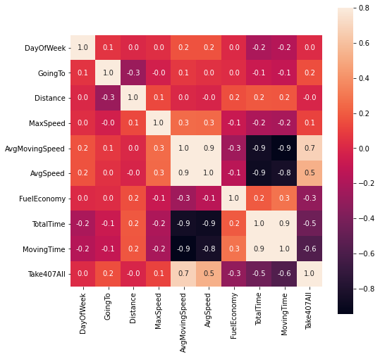

```python
# correlation plot

plt.figure(figsize=(8,8))
sns.heatmap(data.corr(), vmax=.8, square=True, annot=True, fmt=".1f")
```

# Let us focus on MovingTime.

## What are the factors that effect the MovingTime and focus on correlation factors with MovingTime.

**Negative** relationship with MovingTime:

- DayOfWeek
- GoingTo
- MaxSpeed
- AvgMovingSpeed
- AvgSpeed
- Take407All

**Positive** relationship with MovingTime:

- Distance
- FuelEconomy
- TotalTime

[figure not shown]

```python
sns.clustermap(data=data.corr(), annot=True, cmap='Greens')
```

## Heat Map representation in green colour.

[figure not shown]

```python
# plot PairGrid

g = sns.PairGrid(data) #Visualizing the data
g.map(plt.scatter)
```

## Visual Representation of different coloumns Scatter Plot

# As we don't have any specific label. It is better to perform unsupervised machine learning algorithms.

## Aglomerative Clustering

```python
import pandas as pd
import numpy as np
import matplotlib.pyplot as plt
import seaborn as sns
%matplotlib inline

from sklearn.cluster import KMeans
from sklearn.cluster import AgglomerativeClustering
from sklearn.cluster import ward_tree
from scipy.cluster.hierarchy import dendrogram, linkage, ward

from sklearn.metrics import pairwise_distances
```

```python
df=pd.read_csv("/Users/rajivpuli/Desktop/traveltimescleaned.csv") # Using the cleaned dataset for analysis.
print(df.head())
df.head()
```

```
   Unnamed: 0      Date StartTime  DayOfWeek  GoingTo  Distance  MaxSpeed  \
0           0  01/06/12     16:37          5        0     51.29     127.4
1           1  01/06/12      8:20          5        1     51.63     130.3
2           2  01/04/12     16:17          3        1     51.27     127.4
3           3  01/04/12      7:53          3        1     49.17     132.3
4           4  01/03/12     18:57          2        0     51.15     136.2

   AvgMovingSpeed  AvgSpeed  FuelEconomy  TotalTime  MovingTime  Take407All
0            84.8      78.3         8.69       39.3        36.3           0
1            88.9      81.8         8.69       37.9        34.9           0
2            85.8      82.0         8.69       37.5        35.9           0
3            82.9      74.2         8.69       39.8        35.6           0
4            88.1      83.4         8.69       36.8        34.8           0
```

|  | Unnamed: 0 | Date | StartTime | DayOfWeek | GoingTo | Distance | MaxSpeed | AvgMovingSpeed | AvgSpeed | FuelEconomy | TotalTime | MovingTime | Take407All |
| --- | --- | --- | --- | --- | --- | --- | --- | --- | --- | --- | --- | --- | --- |
| 0 | 0 | 01/06/12 | 16:37 | 5 | 0 | 51.29 | 127.4 | 84.8 | 78.3 | 8.69 | 39.3 | 36.3 | 0 |
| 1 | 1 | 01/06/12 | 8:20 | 5 | 1 | 51.63 | 130.3 | 88.9 | 81.8 | 8.69 | 37.9 | 34.9 | 0 |
| 2 | 2 | 01/04/12 | 16:17 | 3 | 1 | 51.27 | 127.4 | 85.8 | 82.0 | 8.69 | 37.5 | 35.9 | 0 |
| 3 | 3 | 01/04/12 | 7:53 | 3 | 1 | 49.17 | 132.3 | 82.9 | 74.2 | 8.69 | 39.8 | 35.6 | 0 |
| 4 | 4 | 01/03/12 | 18:57 | 2 | 0 | 51.15 | 136.2 | 88.1 | 83.4 | 8.69 | 36.8 | 34.8 | 0 |

```python
df = df.drop('Unnamed: 0', axis=1) # Cleaning the data
df.head()
```

|  | Date | StartTime | DayOfWeek | GoingTo | Distance | MaxSpeed | AvgMovingSpeed | AvgSpeed | FuelEconomy | TotalTime | MovingTime | Take407All |
| --- | --- | --- | --- | --- | --- | --- | --- | --- | --- | --- | --- | --- |
| 0 | 01/06/12 | 16:37 | 5 | 0 | 51.29 | 127.4 | 84.8 | 78.3 | 8.69 | 39.3 | 36.3 | 0 |
| 1 | 01/06/12 | 8:20 | 5 | 1 | 51.63 | 130.3 | 88.9 | 81.8 | 8.69 | 37.9 | 34.9 | 0 |
| 2 | 01/04/12 | 16:17 | 3 | 1 | 51.27 | 127.4 | 85.8 | 82.0 | 8.69 | 37.5 | 35.9 | 0 |
| 3 | 01/04/12 | 7:53 | 3 | 1 | 49.17 | 132.3 | 82.9 | 74.2 | 8.69 | 39.8 | 35.6 | 0 |
| 4 | 01/03/12 | 18:57 | 2 | 0 | 51.15 | 136.2 | 88.1 | 83.4 | 8.69 | 36.8 | 34.8 | 0 |

```python
df = df.drop(['Date','StartTime'], axis=1)
df.head()                                    # Removing the unnecessary columns}
```

|  | DayOfWeek | GoingTo | Distance | MaxSpeed | AvgMovingSpeed | AvgSpeed | FuelEconomy | TotalTime | MovingTime | Take407All |
| --- | --- | --- | --- | --- | --- | --- | --- | --- | --- | --- |
| 0 | 5 | 0 | 51.29 | 127.4 | 84.8 | 78.3 | 8.69 | 39.3 | 36.3 | 0 |
| 1 | 5 | 1 | 51.63 | 130.3 | 88.9 | 81.8 | 8.69 | 37.9 | 34.9 | 0 |
| 2 | 3 | 1 | 51.27 | 127.4 | 85.8 | 82.0 | 8.69 | 37.5 | 35.9 | 0 |
| 3 | 3 | 1 | 49.17 | 132.3 | 82.9 | 74.2 | 8.69 | 39.8 | 35.6 | 0 |
| 4 | 2 | 0 | 51.15 | 136.2 | 88.1 | 83.4 | 8.69 | 36.8 | 34.8 | 0 |

```python
dfx = (df - df.mean()) / (df.max() - df.min())
dfx.var()
```

```
DayOfWeek         0.107897
GoingTo           0.249498
Distance          0.013077
MaxSpeed          0.020501
AvgMovingSpeed    0.026771
AvgSpeed          0.026874
FuelEconomy       0.046087
TotalTime         0.016030
MovingTime        0.018761
Take407All        0.142276
dtype: float64
```

# The data is normalized.

```python
np.random.seed(1) # setting random seed to get the same results each time.

agg= AgglomerativeClustering(n_clusters=2, linkage='ward').fit(dfx)
agg.labels_
```

```
array([1, 0, 0, 0, 1, 0, 1, 0, 0, 1, 0, 0, 1, 0, 1, 0, 0, 0, 1, 0, 1, 0,
       1, 0, 0, 1, 0, 1, 0, 1, 0, 1, 0, 1, 1, 0, 1, 0, 1, 0, 1, 0, 1, 0,
       1, 0, 1, 0, 1, 0, 1, 0, 1, 0, 0, 0, 1, 0, 1, 0, 1, 0, 0, 0, 1, 0,
       0, 0, 1, 0, 1, 0, 0, 1, 0, 1, 0, 0, 1, 0, 1, 0, 1, 0, 1, 0, 1, 0,
       1, 0, 0, 1, 0, 1, 0, 0, 0, 1, 0, 1, 0, 1, 0, 1, 0, 1, 0, 1, 0, 1,
       0, 0, 0, 1, 0, 0, 0, 1, 0, 1, 0, 1, 0, 1, 0, 1, 0, 1, 0, 1, 0, 1,
       0, 0, 0, 1, 0, 1, 0, 0, 0, 1, 0, 1, 0, 1, 0, 1, 0, 0, 1, 1, 0, 1,
       0, 1, 0, 1, 0, 0, 0, 1, 0, 1, 0, 1, 0, 1, 0, 1, 0, 1, 0, 1, 0, 1,
       0, 1, 0, 1, 0, 1, 0, 0, 0, 1, 0, 1, 0, 1, 0, 1, 0, 1, 0, 0, 1, 0,
       0, 0, 0, 0, 0, 0, 0])
```

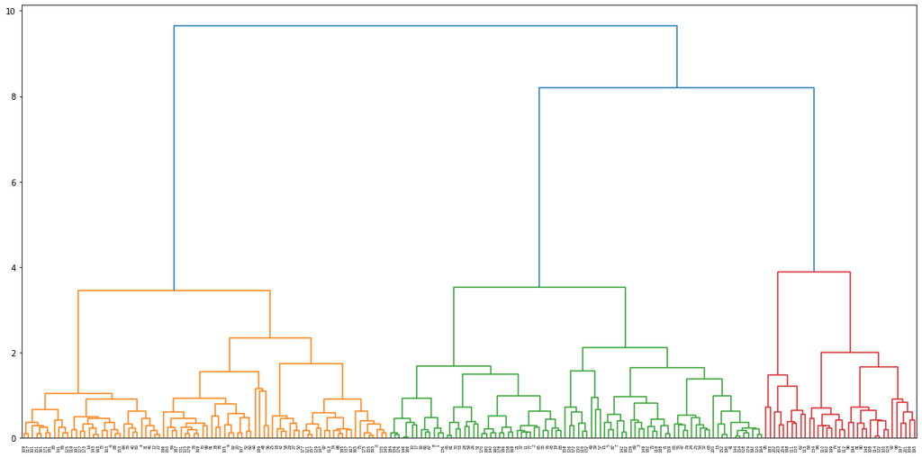

```python
plt.figure(figsize=(16,8))

linkage_matrix = ward(dfx)
dendrogram(linkage_matrix, orientation="top")
plt.tight_layout() # fixes margins
```

# Visual Representation

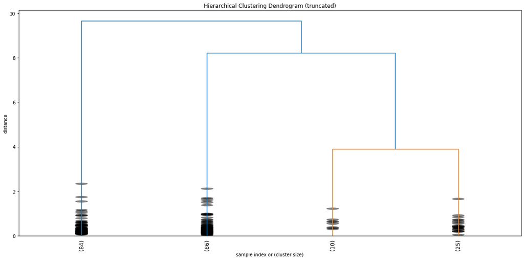

```python
plt.figure(figsize=(16,8))

plt.title('Hierarchical Clustering Dendrogram (truncated)')
plt.xlabel('sample index or (cluster size)')
plt.ylabel('distance')

linkage_matrix = ward(dfx)
dendrogram(linkage_matrix,
           truncate_mode='lastp',  # show only the last p merged clusters
           p=4,  # show only the last p merged clusters
           #show_leaf_counts=False,  # otherwise numbers in brackets are counts
           leaf_rotation=90.,
           leaf_font_size=12.,
           show_contracted=True,  # to get a distribution impression in truncated branches
           orientation="top")
plt.tight_layout() # fixes margins
```

# Difference between the different clusters is shown here.

```python
#To add cluster label into the dataset as a column
df1 = pd.DataFrame(agg.labels_, columns = ['cluster'])
df1.head()
```

|  | cluster |
| --- | --- |
| 0 | 1 |
| 1 | 0 |
| 2 | 0 |
| 3 | 0 |
| 4 | 1 |

# Added cluster label into teh dataset as a column.

```python
df2 = df.join(df1)
df2.head()
```

|  | DayOfWeek | GoingTo | Distance | MaxSpeed | AvgMovingSpeed | AvgSpeed | FuelEconomy | TotalTime | MovingTime | Take407All | cluster |
| --- | --- | --- | --- | --- | --- | --- | --- | --- | --- | --- | --- |
| 0 | 5 | 0 | 51.29 | 127.4 | 84.8 | 78.3 | 8.69 | 39.3 | 36.3 | 0 | 1 |
| 1 | 5 | 1 | 51.63 | 130.3 | 88.9 | 81.8 | 8.69 | 37.9 | 34.9 | 0 | 0 |
| 2 | 3 | 1 | 51.27 | 127.4 | 85.8 | 82.0 | 8.69 | 37.5 | 35.9 | 0 | 0 |
| 3 | 3 | 1 | 49.17 | 132.3 | 82.9 | 74.2 | 8.69 | 39.8 | 35.6 | 0 | 0 |
| 4 | 2 | 0 | 51.15 | 136.2 | 88.1 | 83.4 | 8.69 | 36.8 | 34.8 | 0 | 1 |

# We can see that the new coloumn cluster is added.

```python
df2.groupby('cluster').mean()
```

| cluster | DayOfWeek | GoingTo | Distance | MaxSpeed | AvgMovingSpeed | AvgSpeed | FuelEconomy | TotalTime | MovingTime | Take407All |
| --- | --- | --- | --- | --- | --- | --- | --- | --- | --- | --- |
| 0 | 2.909091 | 0.917355 | 50.807008 | 127.621488 | 83.638017 | 75.607438 | 8.683471 | 41.229752 | 37.068595 | 0.289256 |
| 1 | 2.797619 | 0.000000 | 51.451167 | 127.495119 | 79.580952 | 72.850000 | 8.700714 | 42.876190 | 39.028571 | 0.000000 |

# The mean value of different columns.

```python
df2.groupby('cluster').size()
```

```
cluster
0    121
1     84
dtype: int64
```

## We can see that there are 2 clusters which we created for the data set

## In cluster 1 there are 121 elements and in cluster 2 there are 84 elements.

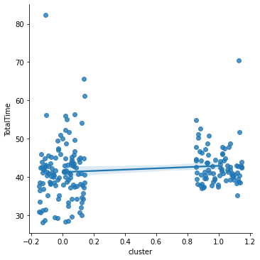

```python
sns.lmplot("cluster", "TotalTime", df2, x_jitter=.15, y_jitter=.15)
```

# We can see that is falling near the line but not perfectly falling in the line.

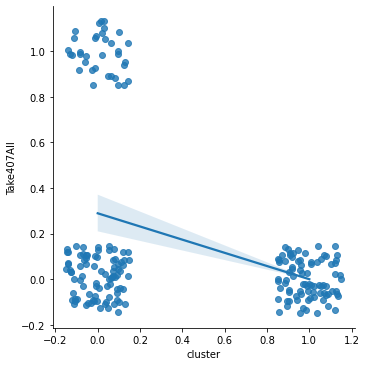

```python
sns.lmplot("cluster", "Take407All", df2, x_jitter=.15, y_jitter=.15)
```

## We can see thet some of the points have fallen too far from the line.

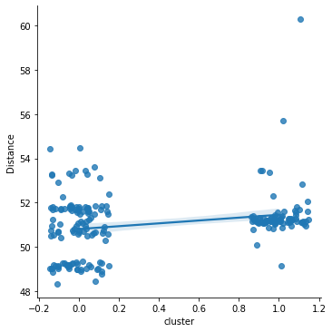

```python
sns.lmplot("cluster", "Distance", df2, x_jitter=.15, y_jitter=.15)
```

### Here also we can see that is falling near the line but not perfectly falling in the line.

# Applying the supervised machine learning considering Take407 column as the label.

## The emphasis here is to to try and develop a model to predict when a Take407 highway affects the other parameters.

```python
import numpy as np
import pandas as pd
import matplotlib.pyplot as plt
import seaborn as sns
%matplotlib inline

#import decisiontreeclassifier
from sklearn import tree
from sklearn.tree import DecisionTreeClassifier, export_graphviz
from IPython.display import SVG
#from graphviz import Source
from IPython.display import display
#import logisticregression classifier
from sklearn.linear_model import LogisticRegression
import statsmodels.api as sm
#import knn classifier
from sklearn.neighbors import KNeighborsClassifier

#for validating your classification model
from sklearn.metrics import classification_report, f1_score, accuracy_score, confusion_matrix
from sklearn.model_selection import StratifiedKFold, cross_val_score, train_test_split, GridSearchCV
from sklearn import metrics
from sklearn.metrics import roc_curve, auc

# feature selection
from sklearn.feature_selection import RFE
from sklearn.ensemble import ExtraTreesClassifier
from sklearn.feature_selection import SelectKBest
from sklearn.feature_selection import chi2


import warnings
warnings.filterwarnings("ignore")
```

```python
df=pd.read_csv("/Users/rajivpuli/Desktop/traveltimescleaned.csv")
print(df.head())
df.head()
```

```
   Unnamed: 0      Date StartTime  DayOfWeek  GoingTo  Distance  MaxSpeed  \
0           0  01/06/12     16:37          5        0     51.29     127.4
1           1  01/06/12      8:20          5        1     51.63     130.3
2           2  01/04/12     16:17          3        1     51.27     127.4
3           3  01/04/12      7:53          3        1     49.17     132.3
4           4  01/03/12     18:57          2        0     51.15     136.2

   AvgMovingSpeed  AvgSpeed  FuelEconomy  TotalTime  MovingTime  Take407All
0            84.8      78.3         8.69       39.3        36.3           0
1            88.9      81.8         8.69       37.9        34.9           0
2            85.8      82.0         8.69       37.5        35.9           0
3            82.9      74.2         8.69       39.8        35.6           0
4            88.1      83.4         8.69       36.8        34.8           0
```

|  | Unnamed: 0 | Date | StartTime | DayOfWeek | GoingTo | Distance | MaxSpeed | AvgMovingSpeed | AvgSpeed | FuelEconomy | TotalTime | MovingTime | Take407All |
| --- | --- | --- | --- | --- | --- | --- | --- | --- | --- | --- | --- | --- | --- |
| 0 | 0 | 01/06/12 | 16:37 | 5 | 0 | 51.29 | 127.4 | 84.8 | 78.3 | 8.69 | 39.3 | 36.3 | 0 |
| 1 | 1 | 01/06/12 | 8:20 | 5 | 1 | 51.63 | 130.3 | 88.9 | 81.8 | 8.69 | 37.9 | 34.9 | 0 |
| 2 | 2 | 01/04/12 | 16:17 | 3 | 1 | 51.27 | 127.4 | 85.8 | 82.0 | 8.69 | 37.5 | 35.9 | 0 |
| 3 | 3 | 01/04/12 | 7:53 | 3 | 1 | 49.17 | 132.3 | 82.9 | 74.2 | 8.69 | 39.8 | 35.6 | 0 |
| 4 | 4 | 01/03/12 | 18:57 | 2 | 0 | 51.15 | 136.2 | 88.1 | 83.4 | 8.69 | 36.8 | 34.8 | 0 |

```python
df = df.drop('Unnamed: 0', axis=1)
df.head()
```

|  | Date | StartTime | DayOfWeek | GoingTo | Distance | MaxSpeed | AvgMovingSpeed | AvgSpeed | FuelEconomy | TotalTime | MovingTime | Take407All |
| --- | --- | --- | --- | --- | --- | --- | --- | --- | --- | --- | --- | --- |
| 0 | 01/06/12 | 16:37 | 5 | 0 | 51.29 | 127.4 | 84.8 | 78.3 | 8.69 | 39.3 | 36.3 | 0 |
| 1 | 01/06/12 | 8:20 | 5 | 1 | 51.63 | 130.3 | 88.9 | 81.8 | 8.69 | 37.9 | 34.9 | 0 |
| 2 | 01/04/12 | 16:17 | 3 | 1 | 51.27 | 127.4 | 85.8 | 82.0 | 8.69 | 37.5 | 35.9 | 0 |
| 3 | 01/04/12 | 7:53 | 3 | 1 | 49.17 | 132.3 | 82.9 | 74.2 | 8.69 | 39.8 | 35.6 | 0 |
| 4 | 01/03/12 | 18:57 | 2 | 0 | 51.15 | 136.2 | 88.1 | 83.4 | 8.69 | 36.8 | 34.8 | 0 |

```python
df.info()
```

```
<class 'pandas.core.frame.DataFrame'>
RangeIndex: 205 entries, 0 to 204
Data columns (total 12 columns):
 #   Column          Non-Null Count  Dtype
---  ------          --------------  -----
 0   Date            205 non-null    object
 1   StartTime       205 non-null    object
 2   DayOfWeek       205 non-null    int64
 3   GoingTo         205 non-null    int64
 4   Distance        205 non-null    float64
 5   MaxSpeed        205 non-null    float64
 6   AvgMovingSpeed  205 non-null    float64
 7   AvgSpeed        205 non-null    float64
 8   FuelEconomy     205 non-null    float64
 9   TotalTime       205 non-null    float64
 10  MovingTime      205 non-null    float64
 11  Take407All      205 non-null    int64
dtypes: float64(7), int64(3), object(2)
memory usage: 19.3+ KB
```